# Tidyverse Problem Set

Dae Hyun Lee

October 4, 2019

### Problem 1

Load the gapminder data from the gapminder package.

How many continents are included in the data set?

```
## [1] "Africa"   "Americas" "Asia"     "Europe"   "Oceania"
```

*There are total 5 continents in the data set.*

How many countrys are included? How many countries per continent?

```
## [1] Afghanistan Albania     Algeria     Angola      Argentina   Australia
## 142 Levels: Afghanistan Albania Algeria Angola Argentina ... Zimbabwe
```

*There are total 142 courtrys are included in the data set.*

Using the gapminder data, produce a report showing the continents in the dataset, total population per continent, and GDP per capita. Be sure that the table is properly labeled and suitable for inclusion in a printed report.

| Continent | Total Population | GDP per Capita |
| --- | --- | --- |
| Africa | 659081517 | 2071.61 |
| Americas | 739274104 | 16566.92 |
| Asia | 3133292191 | 3234.40 |
| Europe | 558142797 | 18420.19 |
| Oceania | 20919651 | 22593.03 |

Produce a well-labeled table that summarizes GDP per capita for the countries in each continent, contrasting the years 1952 and 2007.

GDP per capita by continents in 1952 and in 2007

| Continent | GDP per capita in 1952 | GDP per capita in 2007 |
| --- | --- | --- |
| Africa | 1311.22 | 2560.93 |
| Europe | 6096.66 | 25244.05 |
| Asia | 806.36 | 5432.37 |
| Americas | 8528.04 | 21602.75 |
| Oceania | 10136.10 | 32884.56 |

Product a plot that summarizes the same data as the table. There should be two plots per continent.

[figure not shown]

Which countries in the dataset have had periods of negative population growth? Illustrate your answer with a table or plot.

```
## [1] 109
```

*There are total 109 countries which have had periods of negative population growth.*

Which countries in the dataset have had the highest rate of growth in per capita GDP? Illustrate your answer with a table or plot.

| country | continent | year | lifeExp | pop | gdpPercap | gdpChange |
| --- | --- | --- | --- | --- | --- | --- |
| Kuwait | Asia | 1977 | 69.343 | 1140357 | 59265.477 | 50082.390 |
| Kuwait | Asia | 1982 | 71.309 | 1497494 | 31354.036 | 27911.441 |
| Kuwait | Asia | 1962 | 60.470 | 358266 | 95458.112 | 18065.021 |
| Kuwait | Asia | 1967 | 64.624 | 575003 | 80894.883 | 14563.228 |
| Saudi Arabia | Asia | 1987 | 66.295 | 14619745 | 21198.261 | 12494.914 |
| Iraq | Asia | 1992 | 59.461 | 17861905 | 3745.641 | 7897.932 |
| Gabon | Africa | 1982 | 56.564 | 753874 | 15113.362 | 6632.211 |
| Serbia | Europe | 1992 | 71.659 | 9826397 | 9325.068 | 6545.810 |
| Libya | Africa | 1987 | 66.234 | 3799845 | 11770.590 | 5593.686 |
| Croatia | Europe | 1992 | 72.527 | 4494013 | 8447.795 | 5374.789 |

### Problem 2

The data for Problem 2 is the Fertility data in the AER package. This data is from the 1980 US Census and is comprised of date on married women aged 21-35 with two or more children. The data report the gender of each woman’s first and second child, the woman’s race, age, number of weeks worked in 1979, and whether the woman had more than two children.

There are four possible gender combinations for the first two Children. Product a plot the contracts the frequency of these four combinations. Are the frequencies different for women in their 20s and wemen who are older than 29?

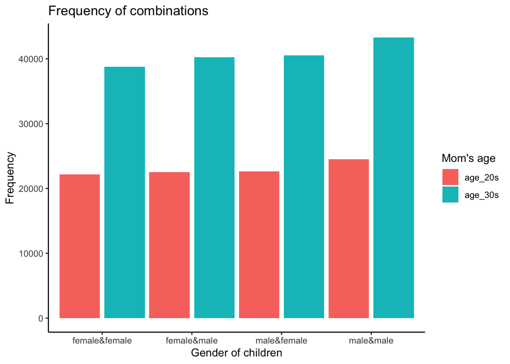

*It is clear that there are differences in frequency between two age groups.*

Produce a plot that contrasts the frequency of having more than two children by race and ethnicity.

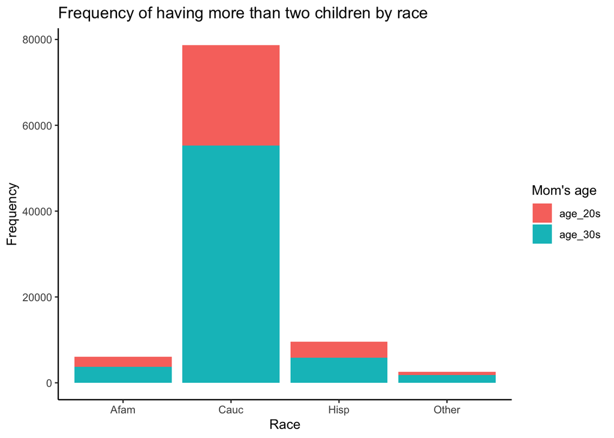

### Problem 3

Use the mtcars and mpg datasets.

How many times does the letter “e” occur in mtcars rownames?

```
## [1] 25
```

*The letter “e” occurs 25 times in mtcars rownames*

How many cars in mtcars have the brand Merc?

```
## [1] 7
```

*7 cars in mtcars have the brand Merc*

How many cars in mpg have the brand(“manufacturer” in mpg) Merc?

```
## [1] 4
```

*There are no such cars that uses the brand Merc in mpg. Instead, there are 4 cars that have brand name mercury*

Contrast the mileage data for Merc cars as reported in mtcars and mpg. Use tables, plots, and a short explanation.

Mileage data for Merc in mpg

| Manufacturer | Model | City miles per gallown | Highways miles per gallon |
| --- | --- | --- | --- |
| mercury | mountaineer 4wd | 14 | 17 |
| mercury | mountaineer 4wd | 13 | 19 |
| mercury | mountaineer 4wd | 13 | 19 |
| mercury | mountaineer 4wd | 13 | 17 |

Mileage data for Merc in mtcars

| Model | Miles/(US)gallon |
| --- | --- |
| Merc 240D | 24.4 |
| Merc 230 | 22.8 |
| Merc 280 | 19.2 |
| Merc 280C | 17.8 |
| Merc 450SE | 16.4 |
| Merc 450SL | 17.3 |
| Merc 450SLC | 15.2 |

### Problem 4

Install the babynames package.

Draw a sample of 500,000 rows from the babynames data

| year | sex | name | n | prop |
| --- | --- | --- | --- | --- |
| 1931 | F | Maryanne | 74 | 0.00006705 |
| 2015 | F | Sira | 7 | 0.00000360 |
| 1913 | F | Aleene | 12 | 0.00001832 |
| 2003 | F | Xochilth | 11 | 0.00000549 |
| 1968 | M | Avis | 12 | 0.00000676 |
| 1952 | F | Krys | 5 | 0.00000263 |
| 1972 | F | Marsha | 1212 | 0.00075164 |
| 1984 | F | Kila | 16 | 0.00000887 |
| 1964 | F | Marquitta | 9 | 0.00000460 |
| 1893 | M | Blaine | 10 | 0.00008262 |

[output cut: 9990 more lines]

Produce a table that displays the five most popular boy names and girl names in the years 1880,1920, 1960, 2000.

The five most popular boy names and girl names

| Rank | 1880 | 1920 | 1960 | 2000 |
| --- | --- | --- | --- | --- |
| #1 | John | Mary | David | Jacob |
| #2 | William | John | Michael | Michael |
| #3 | Mary | William | James | Matthew |
| #4 | James | Robert | John | Joshua |
| #5 | Charles | James | Robert | Emily |

What names overlap boys and girls?

```
## [1] 10663
```

*There are total 10663 overlapping names between boys and girls*

What names were used in the 19th century but have not been used in the 21sth century?

| year | sex | name | n | prop | only |
| --- | --- | --- | --- | --- | --- |
| 1880 | F | Nannie | 248 | 0.00254085 | TRUE |
| 1880 | F | Hulda | 60 | 0.00061472 | TRUE |
| 1880 | F | Gussie | 54 | 0.00055325 | TRUE |
| 1880 | F | Mittie | 53 | 0.00054300 | TRUE |
| 1880 | F | Myrtie | 45 | 0.00046104 | TRUE |
| 1880 | F | Virgie | 41 | 0.00042006 | TRUE |

Produce a chart that shows the relative frequency of the names “Donald”, “Hilary”, “Hillary”, “Joe”, “Barrack”, over the years 1880 through 2017.

| Name | x | prop | proportion |
| --- | --- | --- | --- |
| Donald | 181369 | 0.71355394 | 71.355394 |
| Hilary | 4425 | 0.01740913 | 1.740913 |
| Hillary | 3356 | 0.01320340 | 1.320340 |
| Joe | 65027 | 0.25583353 | 25.583353 |

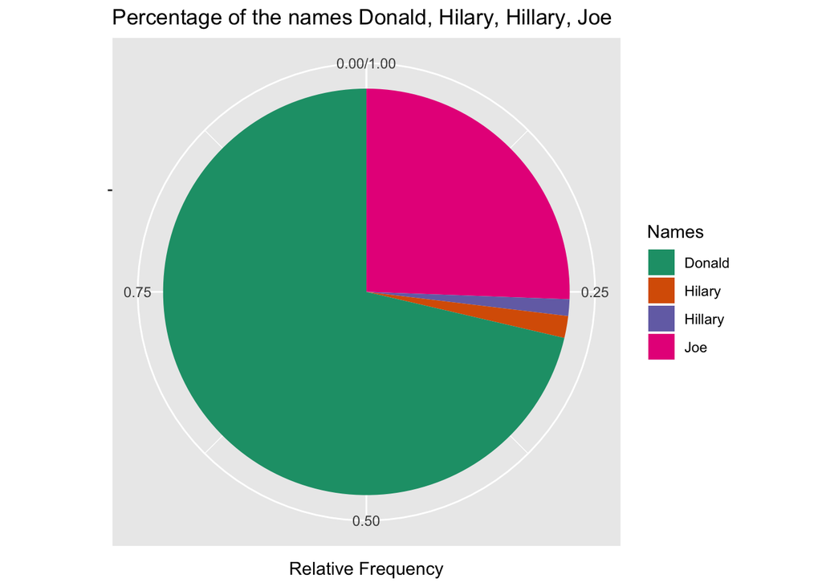